# HW3_TS

Curtis Zhuang

2021/4/19

#### **Question 1:**

#### Load the usgdp.rda dataset and split it into a training dataset (1960 - 2012) and a test dataset (2013 - 2017)

```r
load('usgdp.rda')

train <- subset(usgdp, usgdp$Year < 2013)

test <- subset(usgdp, usgdp $ Year > 2012)

head(train)
```

```
## # A tibble: 6 x 9
##   Country       Code   Year          GDP Growth   CPI Imports Exports Population
##   <fct>         <fct> <dbl>        <dbl>  <dbl> <dbl>   <dbl>   <dbl>      <dbl>
## 1 United States USA    1960 543300000000  NA     13.6    4.20    4.97  180671000
## 2 United States USA    1961 563300000000   2.30  13.7    4.03    4.90  183691000
## 3 United States USA    1962 605100000000   6.1   13.9    4.13    4.81  186538000
## 4 United States USA    1963 638600000000   4.4   14.0    4.09    4.87  189242000
## 5 United States USA    1964 685800000000   5.8   14.2    4.10    5.10  191889000
## 6 United States USA    1965 743700000000   6.40  14.4    4.24    4.99  194303000
```

#### **Question 2:**

#### Plot the training dataset. Is the Box-Cox transformation necessary for this data?

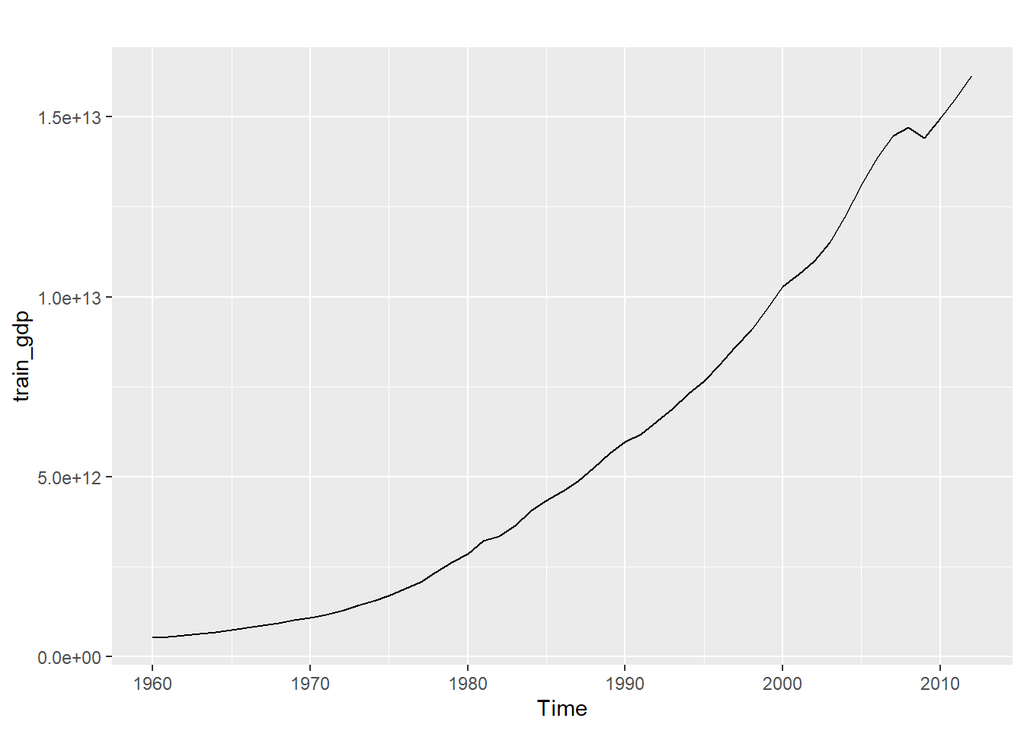

```r
# convert to time series
train_gdp <- ts(train$GDP, start= 1960, frequency = 1)
test_gdp <- ts(test$GDP, start= 2013, frequency = 1)

autoplot(train_gdp)
```

```r
# find the best lambda for transformation
lambda <- BoxCox.lambda(train_gdp)
lambda
```

```
## [1] 0.2310656
```

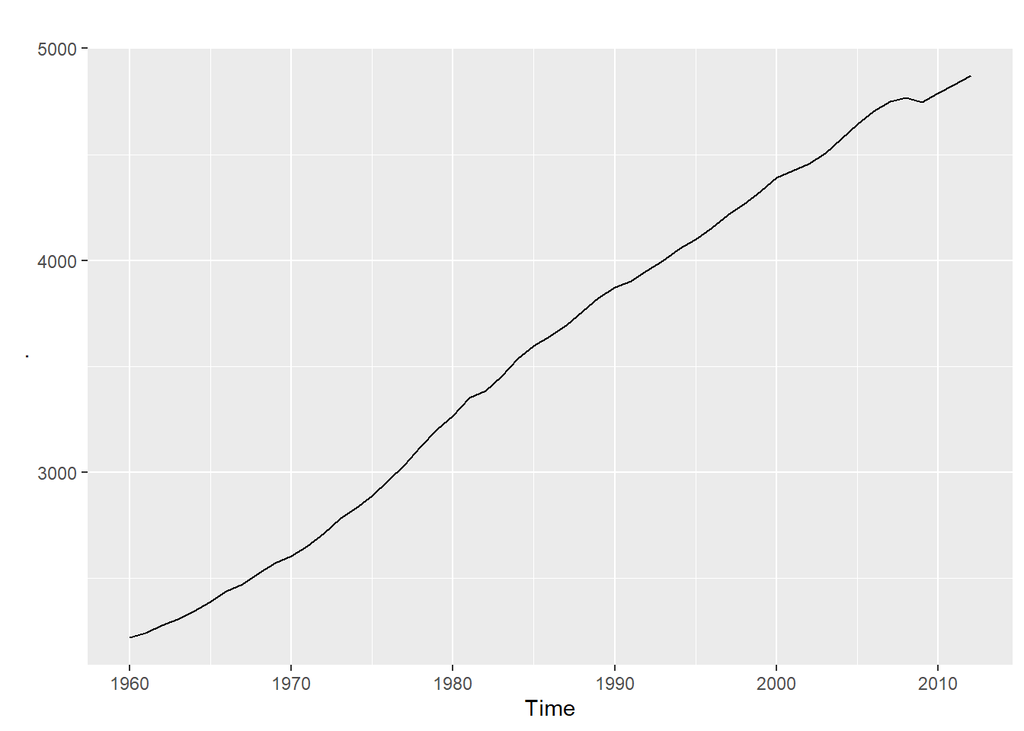

```r
train_gdp %>% BoxCox(lambda = lambda) %>% autoplot()
```

```r
# do transformation based on the best lambda
trans_gdp <- BoxCox(train_gdp, lambda = lambda)
```

**We want to do a transformation with lambda = 0.23 because the original graph as we see is a little concave and we want to make it straight.**

#### **Question 3:**

#### Plot the 1st and 2nd order difference of the data. Apply KPSS Test for Stationarity to determine which difference order results in a stationary dataset.

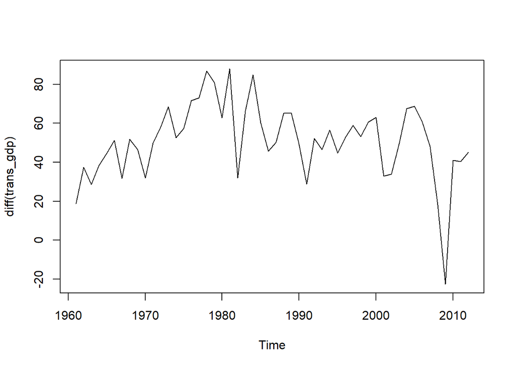

```r
## 1st difference
plot(diff(trans_gdp))
```

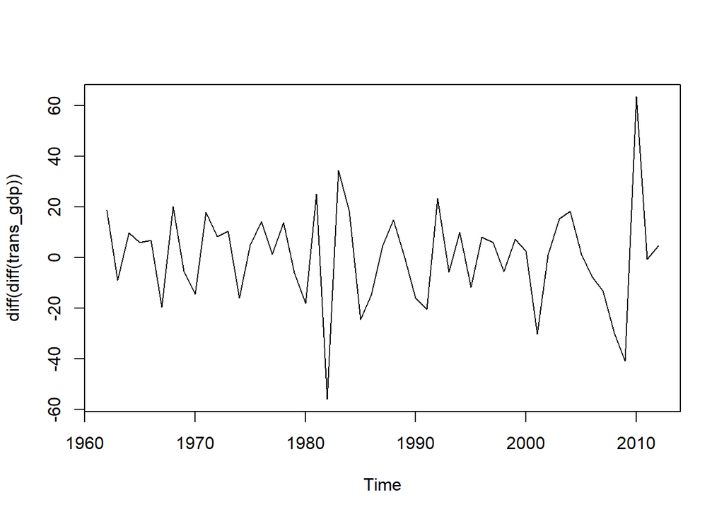

```r
## 2nd difference
plot(diff(diff(trans_gdp)))
```

```r
## kpss for 1st and 2nd order
kpss.test(diff(trans_gdp), null = c("Level", "Trend"), lshort = TRUE)
```

```
##
##  KPSS Test for Level Stationarity
##
## data:  diff(trans_gdp)
## KPSS Level = 0.23261, Truncation lag parameter = 3, p-value = 0.1
```

```r
kpss.test(diff(diff(trans_gdp), null = c("Level", "Trend"), lshort = TRUE))
```

```
##
##  KPSS Test for Level Stationarity
##
## data:  diff(diff(trans_gdp), null = c("Level", "Trend"), lshort = TRUE)
## KPSS Level = 0.10115, Truncation lag parameter = 3, p-value = 0.1
```

**We can choose order 1 as p = 0.1 when using first order. And as the null hypothesis is stationary so we do not want to reject null hypothesis.**

#### **Question 4:**

#### Fit a suitable ARIMA model to the training dataset using the auto.arima() function. Remember to transform the data first if necessary. Report the resulting 𝑝,𝑑,𝑞 and the coefficients values.

```r
fit <- auto.arima(train_gdp, trace = TRUE, lambda = 'auto')
```

```
##
##  ARIMA(2,1,2) with drift         : 454.9046
##  ARIMA(0,1,0) with drift         : 458.4581
##  ARIMA(1,1,0) with drift         : 448.1
##  ARIMA(0,1,1) with drift         : 450.3305
##  ARIMA(0,1,0)                    : 565.303
##  ARIMA(2,1,0) with drift         : 450.4211
##  ARIMA(1,1,1) with drift         : 450.4127
##  ARIMA(2,1,1) with drift         : 452.6492
##  ARIMA(1,1,0)                    : 460.9717
##
##  Best model: ARIMA(1,1,0) with drift
```

```r
fit
```

```
## Series: train_gdp
## ARIMA(1,1,0) with drift
## Box Cox transformation: lambda= 0.2310592
##
## Coefficients:
##          ar1    drift
##       0.4728  50.3273
## s.e.  0.1242   4.3705
##
## sigma^2 estimated as 295.6:  log likelihood=-220.8
## AIC=447.6   AICc=448.1   BIC=453.45
```

```r
Arima(train_gdp, order = c(1,1,0), lambda = lambda, include.drift = T)
```

```
## Series: train_gdp
## ARIMA(1,1,0) with drift
## Box Cox transformation: lambda= 0.2310656
##
## Coefficients:
##          ar1    drift
##       0.4728  50.3366
## s.e.  0.1242   4.3713
##
## sigma^2 estimated as 295.7:  log likelihood=-220.81
## AIC=447.62   AICc=448.12   BIC=453.47
```

**In this case AR order p = 1, transformation coefficient d = 1 and moving average q = 0. AR coefficient is 0.4728 with a drift of 50.3366.**

#### **Question 5:**

#### Compute the sample Extended ACF (EACF) and use the Arima() function to try some other plausible models by experimenting with the orders chosen. Limit your models to 𝑞,𝑝 ≤2 and 𝑑≤2. Use the model summary() function to compare the Corrected Akaike information criterion (i.e., AICc) values (Note: Smaller values indicated better models).

```r
eacf(trans_gdp)
```

```
## AR/MA
##   0 1 2 3 4 5 6 7 8 9 10 11 12 13
## 0 x x x x x x x x x x x  x  o  o
## 1 x o o o o x o o o o o  o  o  o
## 2 o o o o o o o o o o o  o  o  o
## 3 x o o o o o o o o o o  o  o  o
## 4 x o o o o o o o o o o  o  o  o
## 5 x o o o o o o o o o o  o  o  o
## 6 x o o x o o o o o o o  o  o  o
## 7 x x o o o o o o o o o  o  o  o
```

```r
# p = 1, d = 1, q = 1
a111 <- Arima(train_gdp, order = c(1,1,1), lambda = lambda, include.drift = T)
summary(a111)
```

```
## Series: train_gdp
## ARIMA(1,1,1) with drift
## Box Cox transformation: lambda= 0.2310656
##
## Coefficients:
##          ar1      ma1    drift
##       0.5242  -0.0659  50.2622
## s.e.  0.2826   0.3378   4.5322
##
## sigma^2 estimated as 301.5:  log likelihood=-220.79
## AIC=449.58   AICc=450.43   BIC=457.39
##
## Training set error measures:
##                       ME         RMSE         MAE        MPE     MAPE      MASE
## Training set -6789795467 151418485298 83559591389 0.03840439 1.568239 0.2680234
##                    ACF1
## Training set 0.09201069
```

```r
# p = 1, d = 1, q = 2
a112 <- Arima(train_gdp, order = c(1,1,2), lambda = lambda, include.drift = T)
summary(a112)
```

```
## Series: train_gdp
## ARIMA(1,1,2) with drift
## Box Cox transformation: lambda= 0.2310656
##
## Coefficients:
##          ar1      ma1      ma2    drift
##       0.8381  -0.3893  -0.1870  48.9586
## s.e.  0.2026   0.2509   0.1653   6.2791
##
## sigma^2 estimated as 304.5:  log likelihood=-220.54
## AIC=451.08   AICc=452.38   BIC=460.83
##
## Training set error measures:
##                       ME         RMSE         MAE        MPE     MAPE      MASE
## Training set -6285367323 153179627085 85344355805 0.09894245 1.577962 0.2737481
##                   ACF1
## Training set 0.1123169
```

```r
# p = 2, d = 1, q = 1
a211 <- Arima(train_gdp, order = c(2,1,1), lambda = lambda, include.drift = T)
summary(a211)
```

```
## Series: train_gdp
## ARIMA(2,1,1) with drift
## Box Cox transformation: lambda= 0.2310656
##
## Coefficients:
##           ar1     ar2     ma1    drift
##       -0.4832  0.4305  0.9794  50.3988
## s.e.   0.1532  0.1441  0.1077   4.3169
##
## sigma^2 estimated as 305.1:  log likelihood=-220.68
## AIC=451.36   AICc=452.67   BIC=461.12
##
## Training set error measures:
##                       ME         RMSE         MAE        MPE     MAPE      MASE
## Training set -6856595648 150968132421 84374906502 0.03111964 1.571463 0.2706386
##                    ACF1
## Training set 0.03960537
```

```r
# p = 1, d = 2, q = 1
a121 <- Arima(train_gdp, order = c(1,2,1), lambda = lambda, seasonal = F)
summary(a121)
```

```
## Series: train_gdp
## ARIMA(1,2,1)
## Box Cox transformation: lambda= 0.2310656
##
## Coefficients:
##          ar1      ma1
##       0.3138  -0.8217
## s.e.  0.1974   0.1271
##
## sigma^2 estimated as 310.8:  log likelihood=-218
## AIC=441.99   AICc=442.5   BIC=447.79
##
## Training set error measures:
##                        ME         RMSE         MAE       MPE     MAPE      MASE
## Training set -13229410788 158636787310 88117030972 0.2357316 1.614788 0.2826417
##                   ACF1
## Training set 0.1229877
```

```r
# p = 1, d = 2, q = 2
a122 <- Arima(train_gdp, order = c(1,2,2), lambda = lambda)
summary(a122)
```

```
## Series: train_gdp
## ARIMA(1,2,2)
## Box Cox transformation: lambda= 0.2310656
##
## Coefficients:
##          ar1      ma1      ma2
##       0.0780  -0.5676  -0.1805
## s.e.  0.5523   0.5446   0.3656
##
## sigma^2 estimated as 315.8:  log likelihood=-217.87
## AIC=443.75   AICc=444.62   BIC=451.47
##
## Training set error measures:
##                        ME         RMSE         MAE       MPE     MAPE      MASE
## Training set -13497447368 158177546546 87764192936 0.2273486 1.605929 0.2815099
##                   ACF1
## Training set 0.1042622
```

```r
# p = 2, d = 2, q = 1
a221 <- Arima(train_gdp, order = c(2,2,1), lambda = lambda)
summary(a221)
```

```
## Series: train_gdp
## ARIMA(2,2,1)
## Box Cox transformation: lambda= 0.2310656
##
## Coefficients:
##          ar1      ar2      ma1
##       0.2793  -0.1044  -0.7652
## s.e.  0.1996   0.1657   0.1560
##
## sigma^2 estimated as 314.9:  log likelihood=-217.81
## AIC=443.62   AICc=444.49   BIC=451.34
##
## Training set error measures:
##                        ME         RMSE         MAE      MPE     MAPE      MASE
## Training set -13931929828 157926303542 87835712612 0.218507 1.602158 0.2817393
##                    ACF1
## Training set 0.09661786
```

```r
# p = 2, d = 2, q = 2
a222 <- Arima(train_gdp, order = c(2,2,2), lambda = lambda)
summary(a222)
```

```
## Series: train_gdp
## ARIMA(2,2,2)
## Box Cox transformation: lambda= 0.2310656
##
## Coefficients:
##          ar1      ar2      ma1     ma2
##       1.2129  -0.5424  -1.8215  1.0000
## s.e.  0.1253   0.1343   0.1188  0.1274
##
## sigma^2 estimated as 274.6:  log likelihood=-215.88
## AIC=441.77   AICc=443.1   BIC=451.43
##
## Training set error measures:
##                        ME         RMSE         MAE        MPE     MAPE
## Training set -15803350142 140518477863 76861033251 0.08286698 1.425146
##                   MASE       ACF1
## Training set 0.2465373 0.03145839
```

**The best model from EACF is q = 1, d = 2, q = 1 and the AICc is 442.5 which is the smallest among all models.**

#### **Question 6:**

#### Use the model chosen in Question 4 to forecast and plot the GDP forecasts with 80 and 95 % confidence levels for 2013 - 2017 (Test Period).

```r
# get estimate from time series
test.fc <- forecast(fit, h = 5, level = c(80, 95))
test.fc
```

```
##      Point Forecast        Lo 80        Hi 80        Lo 95        Hi 95
## 2013   1.685292e+13 1.652902e+13 1.718167e+13 1.635951e+13 1.735769e+13
## 2014   1.759327e+13 1.700065e+13 1.820163e+13 1.669323e+13 1.853016e+13
## 2015   1.836803e+13 1.752595e+13 1.924088e+13 1.709237e+13 1.971566e+13
## 2016   1.917348e+13 1.809886e+13 2.029650e+13 1.754908e+13 2.091110e+13
## 2017   2.000813e+13 1.871341e+13 2.137065e+13 1.805466e+13 2.212020e+13
```

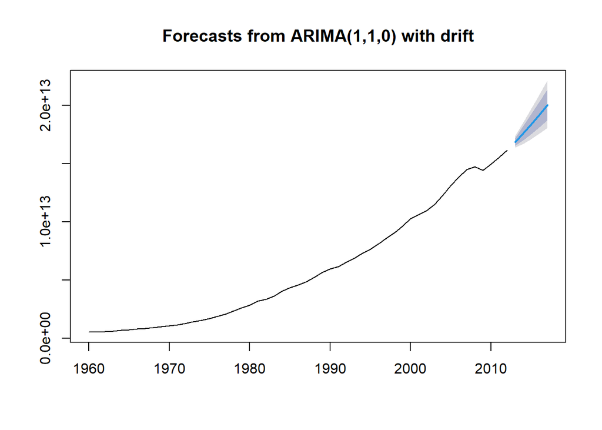

```r
plot(forecast(fit,h=5),include=100)
```

#### **Question 7:**

#### Compare your forecasts with the actual values using error = actual - estimate and plot the errors. (Note: Use the forecast $mean element for the forecast estimate)

```r
# plot the error
error_gdp <- test_gdp - test.fc$mean

error_gdp
```

```
## Time Series:
## Start = 2013
## End = 2017
## Frequency = 1
## [1] -161398579400 -165656059361 -247313993641 -549006695671 -617524534398
```

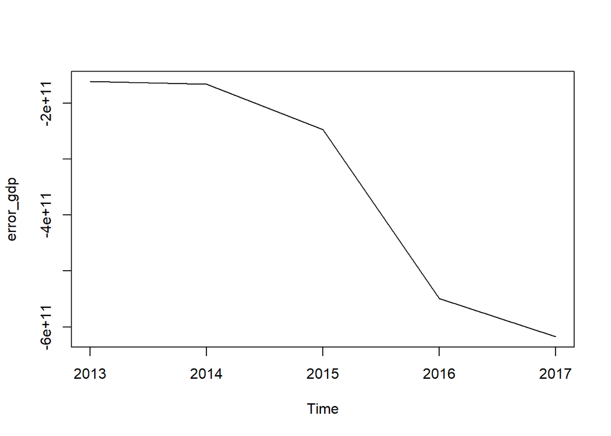

```r
plot(error_gdp)
```

#### **Question 8:**

#### Calculate the sum of squared errors

```r
SSE <- sum(error_gdp^2)
```

**SSE is $7.974*10^{23}$**